# IE 360- HW 1

Tugce Caglayan

2022-04-14

# INTRODUCTION

Economic data can be analyzed as time series data after a certain time and used in forecasting applications. Observed results can depend on many different variables. There may be relationships between variables such as cause-effect or correlation. In this way, more accurate predictions are tried to be obtained for forecasting. In this analysis, the relationship between four different variables-exchange rates (USD/TRY Selling),consumer price index for food,interest rate for personal bank loan,Google search for ‘Market Prices’- and their changes over time are examined. In this study, the following questions will be examined:

1-How has the USD/TRY rate,interest rate and cpi changed from January 2020 to today? 2-How can the relationship between Interest Rate and USD/TRY be explained? 3-How was CPI affected by interest rate and USD/TRY change? 4-How is the relationship between these variables in terms of correlation?

```r
library(openxlsx)
library(ggplot2)
library(data.table)
library(skimr)
library(GGally)
library(ggcorrplot)
library(lubridate)
library(readxl)
library(xts)

Exchange_path='C:/Users/tugce/Desktop/SPRING 2022/IE 360/HW 1/ExchangeRate.xlsx'
Interest_path='C:/Users/tugce/Desktop/SPRING 2022/IE 360/HW 1/Interest Rates.xlsx'
CPI_path='C:/Users/tugce/Desktop/SPRING 2022/IE 360/HW 1/ConsumerPriceIndex.xlsx'
market_fiyatlari_path='C:/Users/tugce/Desktop/SPRING 2022/IE 360/HW 1/multiTimeline.xlsx'
Exchange_Rate=read_excel(Exchange_path)
Interest_Rate=read_excel(Interest_path)
CPI=read_excel(CPI_path)
Market_fiyatlari=read_excel(market_fiyatlari_path)

CPI$Date=as.yearmon(CPI$Date)
Exchange_Rate$Date=as.yearmon(Exchange_Rate$Date)
Interest_Rate$Date=as.yearmon(Interest_Rate$Date)
Market_fiyatlari$Date=as.yearmon(Market_fiyatlari$Date)

CPI=data.table(CPI)
Exchange_Rate=data.table(Exchange_Rate)
Interest_Rate=data.table(Interest_Rate)
Market_fiyatlari=data.table(Market_fiyatlari)
```

# DATA VISUALIZATION AND INTERPRETATION

## 1. Analysis of USD/TRY Exchange Rate

### 1.1 Time Series Plot of USD/TRY Exchange Rate

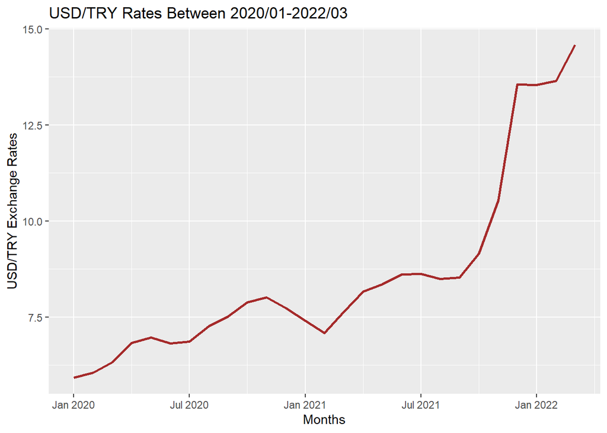

```r
ggplot(Exchange_Rate,aes(x=Date,y=ER,group=1))+ geom_line(color="brown",type="solid",size=1)+ggtitle("USD/TRY Rates Between 2020/01-2022/03")+xlab("Months")+ylab("USD/TRY Exchange Rates")
```

### 1.2 Histogram of USD/TRY Exchange Rate

[figure not shown]

### 1.3 Box-Plot of USD/TRY Exchange Rate

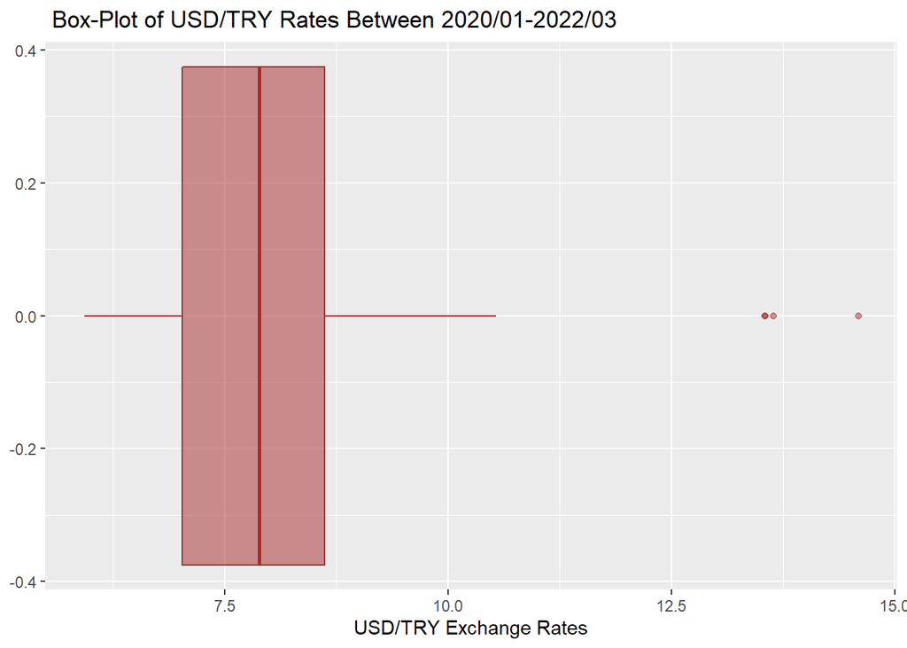

```r
ggplot(Exchange_Rate,aes(x=ER))+ geom_boxplot(color="brown", fill="brown", alpha=0.5)+ggtitle(" Box-Plot of USD/TRY Rates Between 2020/01-2022/03")+xlab("USD/TRY Exchange Rates")
```

## 2. Analysis of Interest Rate

### 2.1 Time Series Plot of Interest Rate

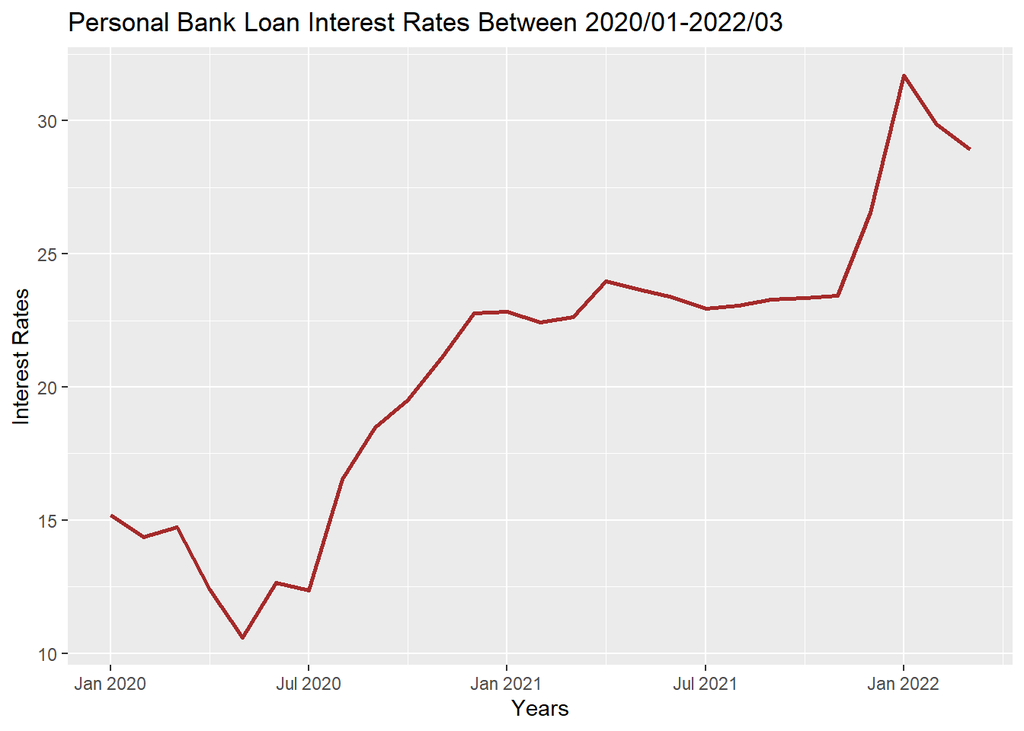

```r
ggplot(Interest_Rate,aes(x=Date,y=IR,group=1))+ geom_line(color="brown",type="solid",size=1)+ggtitle("Personal Bank Loan Interest Rates Between 2020/01-2022/03")+xlab("Years")+ylab("Interest Rates")
```

### 2.2 Histogram of Interest Rate

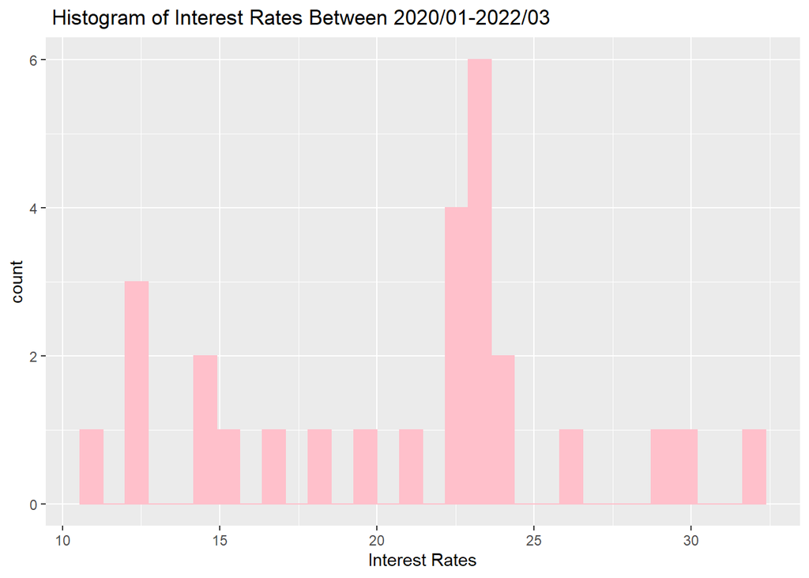

```r
ggplot(Interest_Rate,aes(x=IR))+ geom_histogram(color="pink",fill="pink")+ggtitle(" Histogram of Interest Rates Between 2020/01-2022/03")+xlab("Interest Rates")
```

### 2.3 Box-Plot of Interest Rate

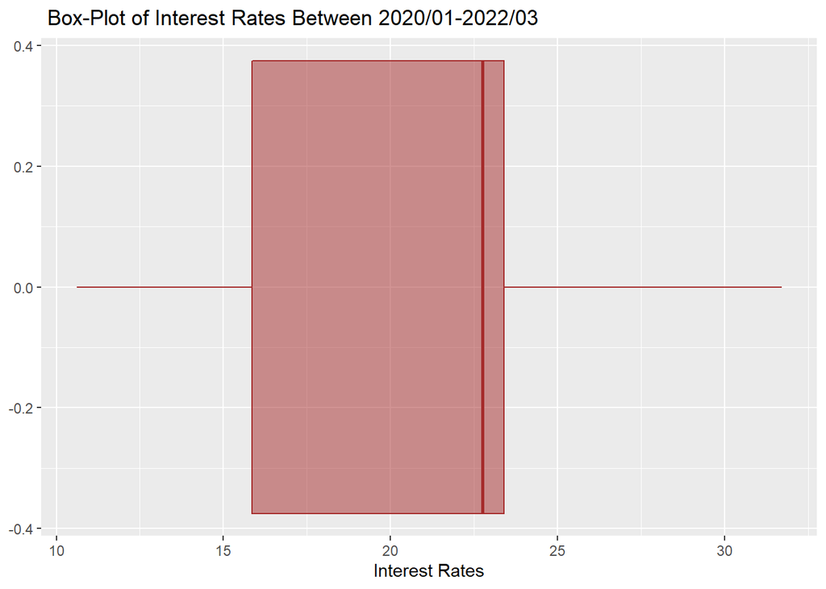

```r
ggplot(Interest_Rate,aes(x=IR))+ geom_boxplot(color="brown", fill="brown", alpha=0.5)+ggtitle(" Box-Plot of Interest Rates Between 2020/01-2022/03")+xlab("Interest Rates")
```

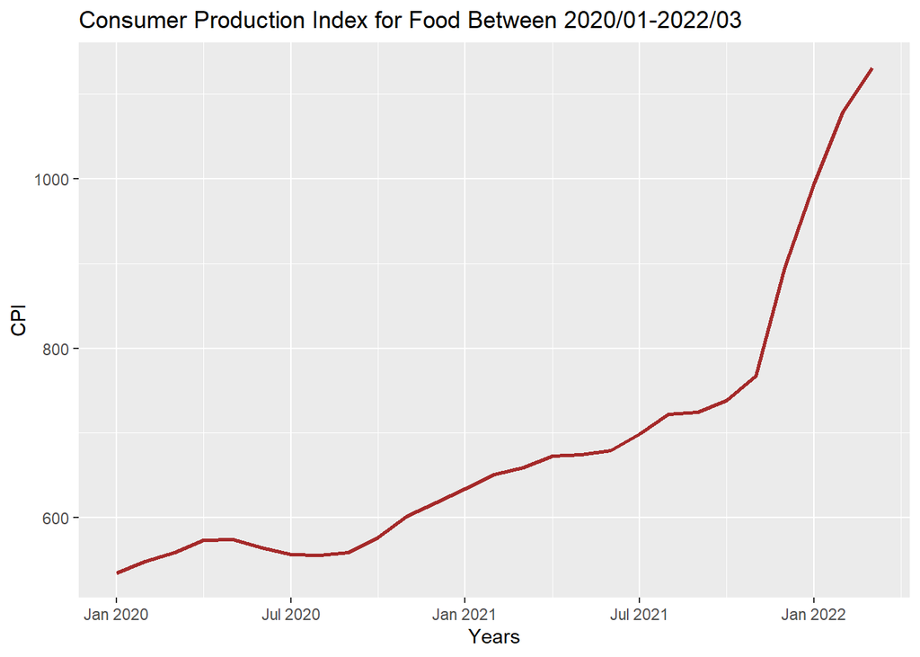

```r
ggplot(CPI,aes(x=Date,y=Consumer_Price_Index,group=1))+ geom_line(color="brown",type="solid",size=1)+ggtitle("Consumer Production Index for Food Between 2020/01-2022/03")+xlab("Years")+ylab("CPI")
```

### 3.2 Histogram of CPI

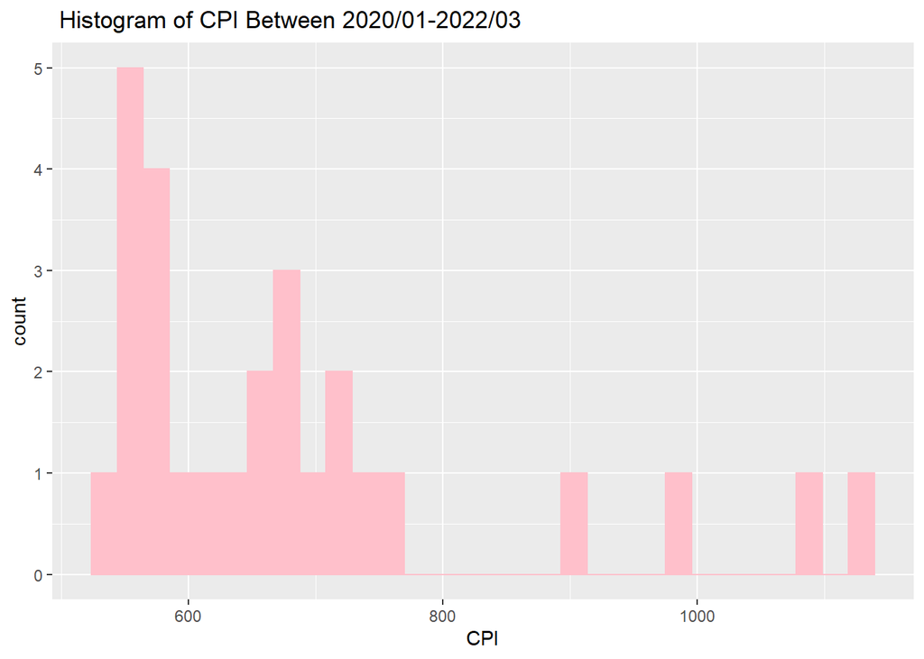

```r
ggplot(CPI,aes(x=Consumer_Price_Index))+ geom_histogram(color="pink",fill="pink")+ggtitle(" Histogram of CPI Between 2020/01-2022/03")+xlab("CPI")
```

### 3.3 Box-Plot of CPI

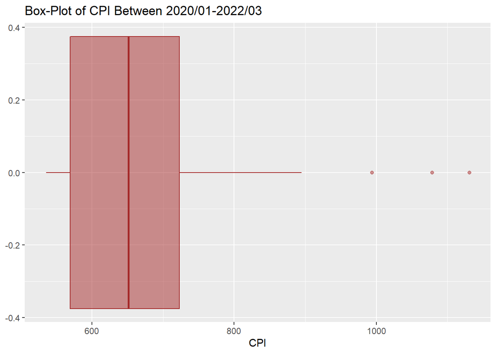

```r
ggplot(CPI,aes(x=Consumer_Price_Index))+ geom_boxplot(color="brown", fill="brown", alpha=0.5)+ggtitle("Box-Plot of CPI Between 2020/01-2022/03")+xlab("CPI")
```

## 4.Analysis of ‘Market Fiyatları’ Search

### 4.1 Time Series Plot of ‘Market Fiyatları’ Search

[figure not shown]

```r
ggplot(Market_fiyatlari,aes(x=Date,y=MF,group=1))+geom_line(color="brown",type="solid",size=1)+ggtitle(" 'Market Fiyatları' Search on Google Between 2020/01-2022/03")+xlab("Years")+ylab("Market Fiyatları Search")
```

### 4.2 Histogram of ‘Market Fiyatları’ Search

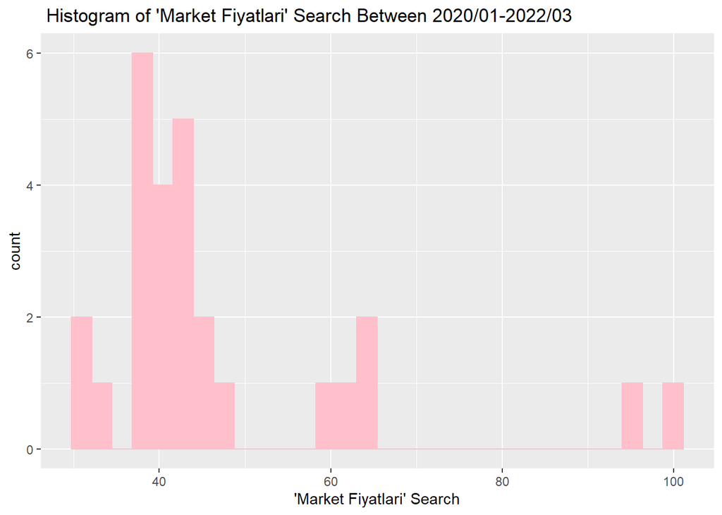

```r
ggplot(Market_fiyatlari,aes(x=MF))+geom_histogram(color="pink",fill="pink")+ggtitle(" Histogram of 'Market Fiyatları' Search Between 2020/01-2022/03")+xlab("'Market Fiyatları' Search")
```

### 4.3 Box-Plot of ‘Market Fiyatları’ Search

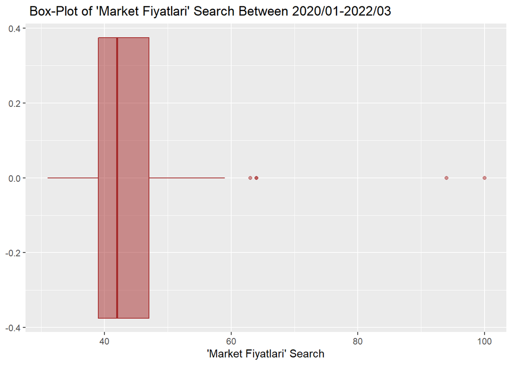

```r
ggplot(Market_fiyatlari,aes(x=MF))+geom_boxplot(color="brown", fill="brown", alpha=0.5)+ggtitle(" Box-Plot of 'Market Fiyatları' Search Between 2020/01-2022/03")+xlab("'Market Fiyatları' Search")
```

# CORRELATION ANALYSIS

## Pairwise Correlation Analysis

```r
data=merge(Exchange_Rate,Interest_Rate,by='Date')
data_new=merge(data,CPI,by='Date')
data_last=merge(data_new,Market_fiyatlari,by='Date')
data_last
```

```
##         Date        ER      IR Consumer_Price_Index  MF
##  1: Jan 2020  5.928827 15.1900               535.37  31
##  2: Feb 2020  6.055370 14.3575               548.59  32
##  3: Mar 2020  6.325805 14.7275               559.40  39
##  4: Apr 2020  6.831252 12.3925               573.63  48
##  5: May 2020  6.964488 10.6080               574.56  42
##  6: Jun 2020  6.821091 12.6650               564.56  37
##  7: Jul 2020  6.863452 12.3680               556.86  39
##  8: Aug 2020  7.265250 16.5350               556.13  33
##  9: Sep 2020  7.521323 18.4900               559.43  37
## 10: Oct 2020  7.888071 19.5020               576.87  44
## 11: Nov 2020  8.017762 21.0825               602.24  39
## 12: Dec 2020  7.734970 22.7600               618.29  45
## 13: Jan 2021  7.407285 22.8180               634.06  42
## 14: Feb 2021  7.085125 22.4200               651.20  41
## 15: Mar 2021  7.641970 22.6425               658.96  41
## 16: Apr 2021  8.169719 23.9800               673.24  46
## 17: May 2021  8.357272 23.6625               674.45  37
## 18: Jun 2021  8.612155 23.3700               679.72  41
## 19: Jul 2021  8.628465 22.9400               699.08  44
## 20: Aug 2021  8.490962 23.0475               721.97  41
## 21: Sep 2021  8.527205 23.2825               724.36  43
## 22: Oct 2021  9.156400 23.3380               738.10  59
## 23: Nov 2021 10.542214 23.4400               767.61  64
## 24: Dec 2021 13.552861 26.5440               894.57  94
## 25: Jan 2022 13.543614 31.7025               993.94  64
## 26: Feb 2022 13.645665 29.8650              1078.58  63
## 27: Mar 2022 14.591843 28.9075              1130.68 100
##         Date        ER      IR Consumer_Price_Index  MF
```

```r
summary(data_last[,c(2:5)])
```

```
##        ER               IR        Consumer_Price_Index       MF
##  Min.   : 5.929   Min.   :10.61   Min.   : 535.4       Min.   : 31.00
##  1st Qu.: 7.025   1st Qu.:15.86   1st Qu.: 569.1       1st Qu.: 39.00
##  Median : 7.888   Median :22.76   Median : 651.2       Median : 42.00
##  Mean   : 8.599   Mean   :20.84   Mean   : 686.9       Mean   : 47.63
##  3rd Qu.: 8.620   3rd Qu.:23.41   3rd Qu.: 723.2       3rd Qu.: 47.00
##  Max.   :14.592   Max.   :31.70   Max.   :1130.7       Max.   :100.00
```

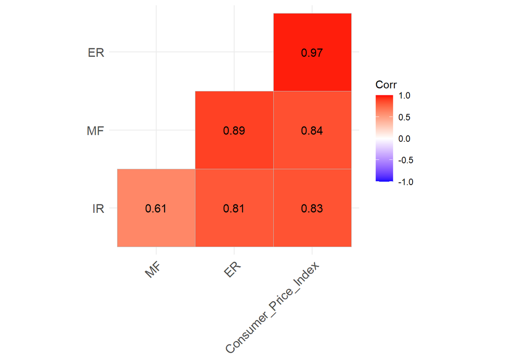

```r
correlation_analysis=cor(data_last[,c(2:5)])
ggcorrplot(correlation_analysis,hc.order = TRUE,type="lower",lab=TRUE)
```

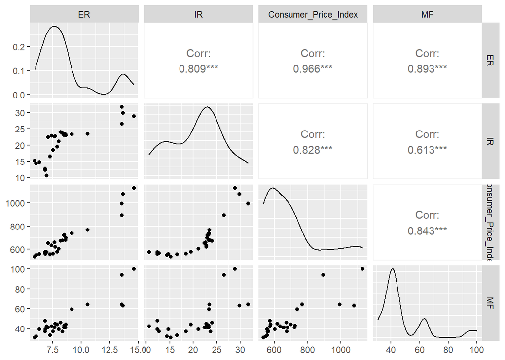

```r
ggpairs(data_last[,c(2:5)])
```